[figure not shown]

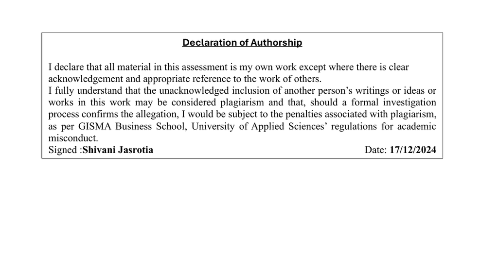

# **Tittle:**

(IMDB Dataset of 50K Movie Reviews)sentiment analysis of movies reviews using transformers.

# **Collection of Dataset**

The IMDB Dataset, comprising 50K Movie Reviews, contains a total of 50,000 critiques of films (each labeled as either positive or negative sentiments). Notably, there is an equal division: 25,000 reviews for each class.

Dataset used for this task click [here](https://https://www.kaggle.com/datasets/lakshmi25npathi/imdb-dataset-of-50k-movie-reviews)

# **Business Problem**

The research was undertaken to illuminate how audiences interpret various films cataloged on IMDB, with a particular emphasis on analyzing reviews associated with these films. The primary objective was to employ machine learning and natural language processing (NLP) techniques to automatically categorize movie reviews into two overarching categories: positive sentiment and negative sentiment. This classification is essential, because it facilitates the accomplishment of multiple business objectives, such as recommending similar films according to audience preferences, marketing movies through targeted advertisements for those that have performed well in audience ratings and assisting movie studios in pinpointing elements that lead to audience dissatisfaction. This information is critical (however), as it enables studios to produce more content that resonates with viewers. Although the primary aim is to deepen the understanding of audience sentiment, it is anticipated that this work will ultimately enhance the customer experience by improving the overall quality of entertainment services they receive.

# **Importing libraries**

```python
import pandas as pd
import numpy as np
import string
import re
from sklearn.model_selection import train_test_split
from sklearn.preprocessing import LabelEncoder
from sklearn.model_selection import train_test_split
from tensorflow.keras.preprocessing.text import Tokenizer
from tensorflow.keras.preprocessing.sequence import pad_sequences
from tensorflow.keras.utils import to_categorical
from tensorflow.keras.models import Sequential
from tensorflow.keras.layers import Embedding, LSTM, Dropout, Dense
from tensorflow.keras.callbacks import ReduceLROnPlateau
import matplotlib.pyplot as plt
from sklearn.model_selection import train_test_split, cross_val_score
from sklearn.linear_model import LogisticRegression
from sklearn.naive_bayes import MultinomialNB
from sklearn.metrics import accuracy_score, classification_report
from sklearn.preprocessing import LabelEncoder
from sklearn.feature_extraction.text import CountVectorizer, TfidfVectorizer
import seaborn as sns
from wordcloud import WordCloud
from sklearn.model_selection import train_test_split
from sklearn.feature_extraction.text import TfidfVectorizer
from sklearn.model_selection import cross_val_score, StratifiedKFold
from wordcloud import WordCloud, STOPWORDS
from sklearn.metrics import accuracy_score, classification_report, confusion_matrix, roc_auc_score, roc_curve
```

# **Loading dataset**

```python
dataframe =pd.read_csv("/content/IMDB Dataset.csv")
data = dataframe.copy()
data.head(7)
```

|  | review | sentiment |
| --- | --- | --- |
| 0 | One of the other reviewers has mentioned that ... | positive |
| 1 | A wonderful little production. <br /><br />The... | positive |
| 2 | I thought this was a wonderful way to spend ti... | positive |
| 3 | Basically there's a family where a little boy ... | negative |
| 4 | Petter Mattei's "Love in the Time of Money" is... | positive |
| 5 | Probably my all-time favorite movie, a story o... | positive |
| 6 | I sure would like to see a resurrection of a u... | positive |

# **Exploring dataset**

Data exploration represents the preliminary phase of data analysis . During this stage, we can scrutinize a dataset to comprehend its attributes and derive insights. This process entails gathering, cleansing and transforming data; furthermore, it includes computing descriptive statistics and visualizing trends with charts and graphs. Data exploration is crucial (because it aids in understanding the data structure, identifying trends and anomalies and formulating hypotheses). Moreover, it facilitates the selection of suitable methods for subsequent analysis or model construction. Although we explore data, we can enhance the accuracy and interpretability of your results; however, one must remain vigilant about potential biases.

```python
data.info()
```

```
<class 'pandas.core.frame.DataFrame'>
RangeIndex: 50000 entries, 0 to 49999
Data columns (total 2 columns):
 #   Column     Non-Null Count  Dtype
---  ------     --------------  -----
 0   review     50000 non-null  object
 1   sentiment  50000 non-null  object
dtypes: object(2)
memory usage: 781.4+ KB
```

```python
data.describe()
```

|  | review | sentiment |
| --- | --- | --- |
| count | 50000 | 50000 |
| unique | 49582 | 2 |
| top | Loved today's show!!! It was a variety and not... | positive |
| freq | 5 | 25000 |

```python
sns.countplot(x='sentiment', data=data)
plt.title("Class Distribution")
plt.show()
```

[figure not shown]

```python
# Generate a word cloud for positive reviews
positive_reviews = " ".join(data[data['sentiment'] == 'positive']['review'])
wordcloud = WordCloud(width=800, height=400, background_color='white').generate(positive_reviews)
plt.figure(figsize=(10, 5))
plt.imshow(wordcloud, interpolation='bilinear')
plt.axis('off')
plt.title("Word Cloud for Positive Reviews")
plt.show()
```

[figure not shown]

```python
negative_reviews = " ".join(data[data['sentiment'] == 'negative']['review'].sample(n=1000, random_state=42))
stopwords = set(STOPWORDS)
stopwords.update(["br", "movie", "film", "one", "even", "like", "would", "get"])
wordcloud = WordCloud(width=800, height=400,
                      background_color='white',
                      stopwords=stopwords,
                      max_words=150,
                      min_font_size=10).generate(negative_reviews)
plt.figure(figsize=(10, 5))
plt.imshow(wordcloud, interpolation='bilinear')
plt.axis('off')
plt.title("Word Cloud for Negative Reviews")
plt.tight_layout(pad=0)
plt.show()
```

[figure not shown]

```python
data.isnull().sum()
data.duplicated().sum()
data.dropna(inplace=True)
data.isnull().sum()
```

|  | 0 |
| --- | --- |
| review | 0 |
| sentiment | 0 |

**dtype:** int64

# **Text Preprocessing**

Data cleansing and preprocessing (a vital step): it involves purging raw review text of HTML tags, URLs and non-ASCII characters, while also converting everything to lowercase. This process tokenizes and lemmatizes the text, which means it reduces words to their base forms; however, it also eliminates common English stop words. Although necessary, some might find this tedious because it is essential for ensuring data quality.

```python
!pip install nltk
import nltk
nltk.download('punkt_tab')
from nltk.tokenize import word_tokenize, sent_tokenize
from nltk.corpus import stopwords
from nltk.stem import WordNetLemmatizer
nltk.download('punkt')
nltk.download('stopwords')
nltk.download('wordnet')
sampled_data = data.sample(frac=0.1, random_state=42)

df = pd.DataFrame({'review': ['This is a sample review. It needs cleaning!',
                                  'Here is another example of text. Lemmatize it!']})
lemmatizer = WordNetLemmatizer()
stop_words = set(stopwords.words('english'))

def preprocess_text(text):
    text = re.sub(r'<.*?>', '', text)
    text = re.sub(r'http\S+|www\S+|https\S+', '', text, flags=re.MULTILINE)
    text = re.sub(r'[^\x00-\x7F]+', '', text)
    text = text.lower()
    text = re.sub(r'[\d\W]+', ' ', text)
    return text
def tokenize_and_lemmatize(text):
    sentences = sent_tokenize(text)
    processed_sentences = []

    for sentence in sentences:
        words = word_tokenize(sentence)
        lemmatized_words = [lemmatizer.lemmatize(word) for word in words if word.lower() not in stop_words]
        processed_sentences.append(' '.join(lemmatized_words))
    return ' '.join(processed_sentences)
data['cleaned_text'] = data['review'].apply(preprocess_text)
data['processed_text'] = data['cleaned_text'].apply(tokenize_and_lemmatize)
print(data[['review', 'cleaned_text', 'processed_text']])
```

```
                                                  review  \
0      One of the other reviewers has mentioned that ...
1      A wonderful little production. <br /><br />The...
2      I thought this was a wonderful way to spend ti...
3      Basically there's a family where a little boy ...
4      Petter Mattei's "Love in the Time of Money" is...
...                                                  ...
49995  I thought this movie did a down right good job...
49996  Bad plot, bad dialogue, bad acting, idiotic di...
49997  I am a Catholic taught in parochial elementary...
49998  I'm going to have to disagree with the previou...
49999  No one expects the Star Trek movies to be high...

                                            cleaned_text  \
0      one of the other reviewers has mentioned that ...
```

[output cut: 25 more lines]

Feature extraction involves generating numerical representations of textual data through two primary methodologies: Bag-of-Words (BoW), which counts the occurrences of words within each document and TF-IDF, which weighs the significance of words according to their frequency in a specific document and across the entire corpus. However, these methods impose a limitation on vocabulary size, capping it at the 5000 most frequently used words. This is important because it ensures manageability and efficiency in processing the data, although it may exclude some less common terms that could be relevant.

```python
sampled_data['cleaned_text'] = sampled_data['review'].apply(preprocess_text)
sampled_data['processed_text'] = sampled_data['cleaned_text'].apply(tokenize_and_lemmatize)
x = sampled_data['processed_text'].astype(str).tolist()
from sklearn.preprocessing import LabelEncoder
le = LabelEncoder()
y = le.fit_transform(sampled_data['sentiment']).tolist()
x_train, x_test, y_train, y_test = train_test_split(x, y, test_size=0.2, random_state=42)
vectorizer_bow = CountVectorizer(max_features=5000)
X_train_bow = vectorizer_bow.fit_transform(x_train)
X_test_bow = vectorizer_bow.transform(x_test)

print(f"Shape of Bag of Words representation (train): {X_train_bow.shape}")
print(f"Shape of Bag of Words representation (test): {X_test_bow.shape}")

vectorizer_tfidf = TfidfVectorizer(max_features=5000)
X_train_tfidf = vectorizer_tfidf.fit_transform(x_train)
X_test_tfidf = vectorizer_tfidf.transform(x_test)

print(f"Shape of TF-IDF representation (train): {X_train_tfidf.shape}")
print(f"Shape of TF-IDF representation (test): {X_test_tfidf.shape}")

print(f"BoW feature names: {vectorizer_bow.get_feature_names_out()[:10]}")
print(f"TF-IDF feature names: {vectorizer_tfidf.get_feature_names_out()[:10]}")
```

```
Shape of Bag of Words representation (train): (4000, 5000)
Shape of Bag of Words representation (test): (1000, 5000)
Shape of TF-IDF representation (train): (4000, 5000)
Shape of TF-IDF representation (test): (1000, 5000)
BoW feature names: ['abandoned' 'abbott' 'abc' 'ability' 'able' 'abrupt' 'absence' 'absent'
 'absolute' 'absolutely']
TF-IDF feature names: ['abandoned' 'abbott' 'abc' 'ability' 'able' 'abrupt' 'absence' 'absent'
 'absolute' 'absolutely']
```

# **Traditional Methods**

1. LogesticRegression.
2. Naive Bayes.

```python
from sklearn.linear_model import LogisticRegression

models = {
    'Logistic Regression': LogisticRegression(max_iter=200),
    'Naive Bayes': MultinomialNB()
}


cv = StratifiedKFold(n_splits=5, shuffle=True, random_state=42)

for model_name, model in models.items():
    print(f"\nTraining {model_name}...")


    cv_scores = cross_val_score(model, X_train_tfidf, y_train, cv=cv, scoring='accuracy')
    print(f"Cross-Validation Accuracy: {cv_scores.mean():.4f} (+/- {cv_scores.std():.4f})")

    model.fit(X_train_tfidf, y_train)
    y_pred = model.predict(X_test_tfidf)
    y_pred_prob = model.predict_proba(X_test_tfidf)[:, 1] if hasattr(model, 'predict_proba') else None

    print(f"Test Set Accuracy: {accuracy_score(y_test, y_pred):.4f}")
    print("Classification Report:")
    print(classification_report(y_test, y_pred))

    if y_pred_prob is not None:
        auc_score = roc_auc_score(y_test, y_pred_prob)
        print(f"ROC-AUC Score: {auc_score:.4f}")
        fpr, tpr, _ = roc_curve(y_test, y_pred_prob)
        plt.plot(fpr, tpr, label=f"{model_name} (AUC = {auc_score:.4f})")
plt.xlabel('False Positive Rate')
plt.ylabel('True Positive Rate')
plt.title('ROC Curve')
plt.legend()
plt.show()
```

```
Training Logistic Regression...
Cross-Validation Accuracy: 0.8478 (+/- 0.0091)
Test Set Accuracy: 0.8510
Classification Report:
              precision    recall  f1-score   support

           0       0.88      0.81      0.85       506
           1       0.82      0.89      0.85       494

    accuracy                           0.85      1000
   macro avg       0.85      0.85      0.85      1000
weighted avg       0.85      0.85      0.85      1000

ROC-AUC Score: 0.9274

Training Naive Bayes...
Cross-Validation Accuracy: 0.8433 (+/- 0.0120)
Test Set Accuracy: 0.8420
Classification Report:
              precision    recall  f1-score   support

           0       0.84      0.85      0.84       506
           1       0.84      0.84      0.84       494

    accuracy                           0.84      1000
   macro avg       0.84      0.84      0.84      1000
weighted avg       0.84      0.84      0.84      1000

ROC-AUC Score: 0.9212
```

[figure not shown]

```python
#  for results
results_df = pd.DataFrame(results)
print("\nModel Performance:")
print(results_df.sort_values(by=['Test Accuracy', 'ROC-AUC'], ascending=False))
```

[output not shown]

# *Deep Learning*

There are various neural network architectures are used for text classification are mentioned below.

Transformers

- Convolutional neural networks (CNNs)
- Recurrent neural networks (RNNs)
- Long short-term memory (LSTM)
- Transformers

# **Transformers**

The Transformer model represents a sophisticated neural network architecture that is fundamentally based on self-attention mechanisms which process sequential data, such as text and audio. Although RNNs (Recurrent Neural Networks) handle data in a sequential manner, this particular structure enables the parallelization of training, thus significantly accelerating the process. The essence of learning within the Transformer lies in the encoder-decoder architecture of any given type, which effectively translates the input features extracted by the encoder into the corresponding output sequence via a decoder. The attention mechanism available facilitates the model's ability to concentrate on various segments of the input sequence when generating the output; this capability enables it to capture long-range dependencies and intricate relationships within the data. These advancements have rendered the Transformer remarkably effective for tasks such as machine translation, text summarization and question answering. However, its complexity may present challenges in certain applications.

# **1 Simple transformers Model**

```python
!pip install simpletransformers
!pip install sklearn
```